# Portfolio Optimization

Chloe Bouton

2025-05-01

## Load Required Packages

```r
library(quantmod)
library(PerformanceAnalytics)
library(PortfolioAnalytics)
library(ROI)
library(ROI.plugin.quadprog)
library(ROI.plugin.glpk)
library(ROI.plugin.symphony)
library(CVXR)
```

```r
library(corrplot)
```

- **quantmod** for financial data retrieval
- **PerformanceAnalytics** for performance measurement
- **PortfolioAnalytics** for portfolio optimization framework
- **ROI.plugin.quadprog** for quadratic programming solver

## Data Acquisition and Preprocessing

```r
# Define ticker symbols
tickers <- c("AAPL", "MSFT", "GOOGL", "JPM", "XOM")

# Get 5 years of monthly price data
getSymbols(tickers,
           src = "yahoo",
           from = "2020-05-01",
           to = "2025-05-01")
```

```
## [1] "AAPL"  "MSFT"  "GOOGL" "JPM"   "XOM"
```

```r
prices <- do.call(merge, lapply(tickers, function(sym) Ad(get(sym))))
colnames(prices) <- tickers

returns <- na.omit(Return.calculate(prices))
```

## Performance Analysis and Risk Metrics

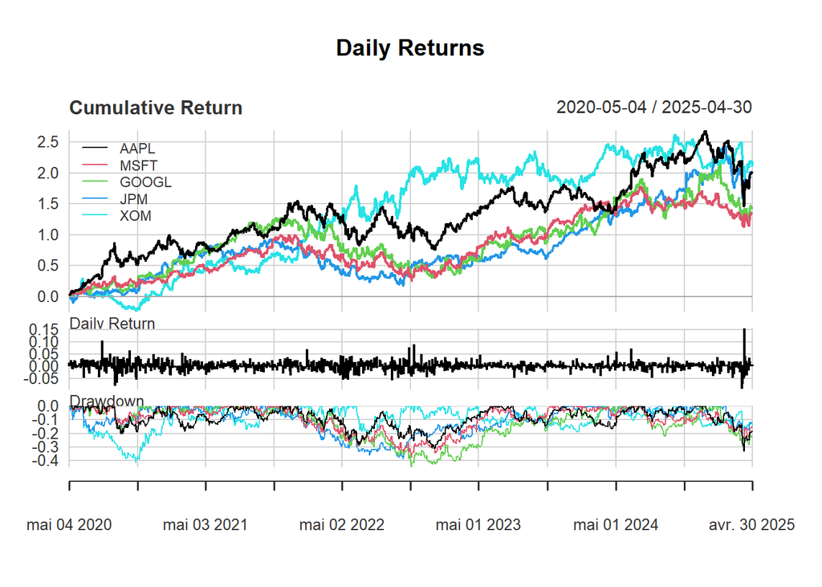

```r
# Performance summary
charts.PerformanceSummary(returns,
                          main = "Daily Returns",
                          legend.loc = "topleft")
```

```r
# Risk metrics
table.Stats(returns)
```

```
##                      AAPL      MSFT     GOOGL       JPM       XOM
## Observations    1255.0000 1255.0000 1255.0000 1255.0000 1255.0000
## NAs                0.0000    0.0000    0.0000    0.0000    0.0000
## Minimum           -0.0925   -0.0772   -0.0951   -0.0834   -0.0883
## Quartile 1        -0.0082   -0.0080   -0.0095   -0.0079   -0.0105
## Median             0.0013    0.0009    0.0015    0.0010    0.0007
## Arithmetic Mean    0.0011    0.0008    0.0009    0.0010    0.0011
## Geometric Mean     0.0009    0.0007    0.0007    0.0009    0.0009
## Quartile 3         0.0119    0.0106    0.0114    0.0099    0.0119
## Maximum            0.1533    0.1013    0.1022    0.1354    0.1266
## SE Mean            0.0005    0.0005    0.0005    0.0005    0.0005
## LCL Mean (0.95)    0.0000   -0.0001   -0.0002    0.0001    0.0000
## UCL Mean (0.95)    0.0021    0.0018    0.0020    0.0020    0.0022
## Variance           0.0004    0.0003    0.0004    0.0003    0.0004
## Stdev              0.0188    0.0170    0.0194    0.0171    0.0193
## Skewness           0.3515    0.0469    0.0076    0.5377    0.2056
## Kurtosis           5.6749    2.5486    2.9359    6.5599    2.6015
```

```r
table.AnnualizedReturns(returns)
```

```
##                             AAPL   MSFT  GOOGL    JPM    XOM
## Annualized Return         0.2492 0.1887 0.1944 0.2480 0.2554
## Annualized Std Dev        0.2986 0.2697 0.3086 0.2720 0.3070
## Annualized Sharpe (Rf=0%) 0.8348 0.6998 0.6300 0.9118 0.8319
```

```r
table.DownsideRisk(returns)
```

```
##                                  AAPL    MSFT   GOOGL     JPM     XOM
## Semi Deviation                 0.0132  0.0121  0.0139  0.0118  0.0134
## Gain Deviation                 0.0133  0.0114  0.0131  0.0127  0.0134
## Loss Deviation                 0.0129  0.0116  0.0134  0.0114  0.0123
## Downside Deviation (MAR=210%)  0.0174  0.0165  0.0181  0.0161  0.0177
## Downside Deviation (Rf=0%)     0.0127  0.0117  0.0134  0.0113  0.0129
## Downside Deviation (0%)        0.0127  0.0117  0.0134  0.0113  0.0129
## Maximum Drawdown               0.3336  0.3715  0.4432  0.3877  0.4119
## Historical VaR (95%)          -0.0298 -0.0270 -0.0307 -0.0263 -0.0291
## Historical ES (95%)           -0.0416 -0.0379 -0.0436 -0.0372 -0.0410
## Modified VaR (95%)            -0.0258 -0.0260 -0.0299 -0.0222 -0.0285
## Modified ES (95%)             -0.0313 -0.0378 -0.0446 -0.0222 -0.0394
```

```r
VaR(returns, p = 0.95, method = "historical")
```

```
##            AAPL        MSFT       GOOGL         JPM         XOM
## VaR -0.02979253 -0.02697327 -0.03074215 -0.02632022 -0.02910539
```

```r
ES(returns, p = 0.95, method = "historical")
```

```
##           AAPL        MSFT       GOOGL       JPM         XOM
## ES -0.04163967 -0.03788462 -0.04364204 -0.037223 -0.04097579
```

## Correlation Analysis

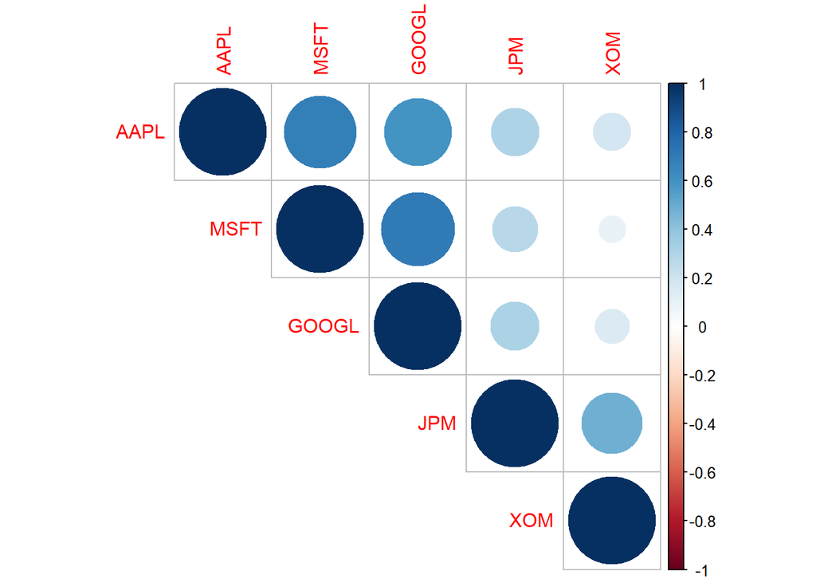

```r
# Correlation matrix
cor_matrix <- cor(returns)
corrplot::corrplot(cor_matrix,
                   method = "circle",
                   type = "upper")
```

```r
# Covariance matrix
cov_matrix <- cov(returns)
```

## Portfolio Optimization Setup

```r
# Define Portfolio
port_spec <- portfolio.spec(assets = colnames(returns))

# Add constraints
port_spec <- add.constraint(portfolio = port_spec,
                            type = "full_investment")

port_spec <- add.constraint(portfolio = port_spec,
                            type = "long_only")

# Add objectives
port_spec <- add.objective(portfolio = port_spec,
                           type = "risk",
                           name = "StdDev")

port_spec <- add.objective(portfolio = port_spec,
                           type = "return",
                           name = "mean")
```

## Optimization Results and Efficient Frontier

```r
# Optimization
opt_result <- optimize.portfolio(R = returns,
                                 portfolio = port_spec,
                                 optimize_method = "ROI",
                                 trace = TRUE)

opt_result
```

```
## PortfolioAnalytics Optimization
##
## Call:
## optimize.portfolio(R = returns, portfolio = port_spec, optimize_method = "ROI",
##     trace = TRUE)
##
## Optimal Weights:
##   AAPL   MSFT  GOOGL    JPM    XOM
## 0.3882 0.0000 0.0000 0.2515 0.3603
##
## Objective Measure:
##     mean
## 0.001062
##
##
##  StdDev
## 0.01367
```

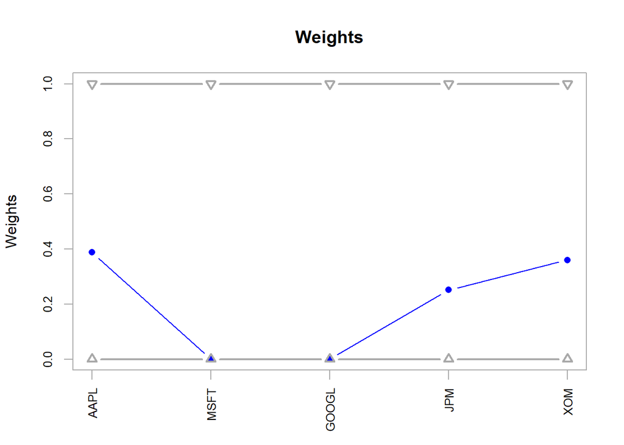

```r
chart.Weights(opt_result)
```

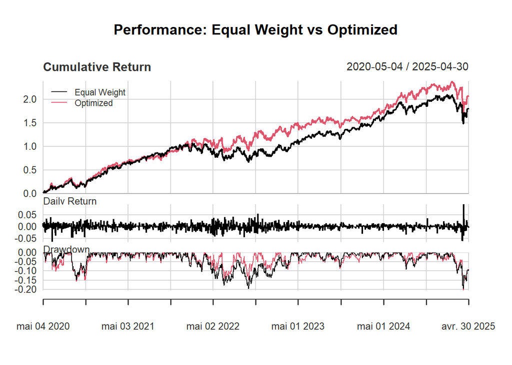

```r
# Equal-weight portfolio returns
equal_weights <- rep(1 / ncol(returns), ncol(returns))
ew_returns <- Return.portfolio(returns,
                               weights = equal_weights)

# Optimized portfolio returns
opt_weights <- extractWeights(opt_result)
opt_returns <- Return.portfolio(returns,
                                weights = opt_weights)

# Combine and plot
combined <- merge.xts(ew_returns, opt_returns)
colnames(combined) <- c("Equal Weight", "Optimized")
charts.PerformanceSummary(combined, main = "Performance: Equal Weight vs Optimized")
```

```r
# Efficient frontier
ef <- create.EfficientFrontier(returns,
                               port_spec,
                               type = "mean-StdDev")
```

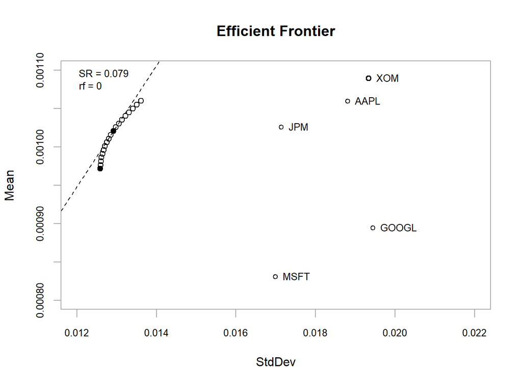

```r
chart.EfficientFrontier(ef,
                        match.col = "StdDev",
                        n.portfolios = 25,
                        main = "Efficient Frontier",
                        xlim = c(0.012, 0.022),
                        ylim = c(0.0008, 0.0011))
```

Given the correlations observed earlier, it is no surprise that only one stock among Apple, Microsoft, and Google was selected for the optimized portfolio, alongside the two remaining stocks, JPM and XOM.

Reviewing the annualized returns and volatility calculated at the beginning:

AAPL’s higher annualized return and Sharpe ratio, compared to its counterparts, explain why it was chosen among the three highly correlated stocks.

## Risk Contribution Analysis

```r
opt_weights <- as.numeric(opt_weights)

# Portfolio volatility
port_volatility <- sqrt(sum(opt_weights * (cov_matrix %*% opt_weights)))

# Risk contribution for each asset
risk_contrib <- (cov_matrix %*% opt_weights) * opt_weights / port_volatility

# Convert to a data frame
risk_contrib_df <- data.frame(Asset = colnames(returns), RiskContribution = risk_contrib)

print(risk_contrib_df)
```

```
##       Asset RiskContribution
## AAPL   AAPL     5.277447e-03
## MSFT   MSFT    -1.336399e-19
## GOOGL GOOGL     0.000000e+00
## JPM     JPM     3.106688e-03
## XOM     XOM     5.289243e-03
```

The risk contribution table can be directly explained by weight allocaton seen above.

## Backtesting

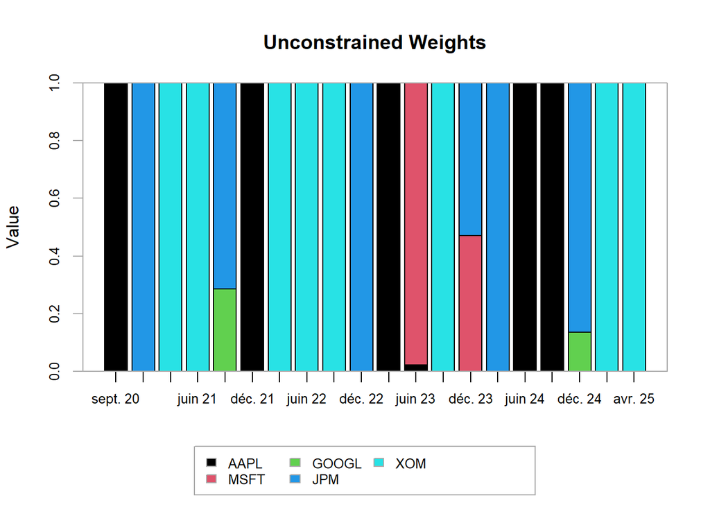

```r
benchmark_returns <- Return.portfolio(R = returns,
                                      weights = equal_weights,
                                      rebalance_on = "years")

colnames(benchmark_returns) <-"benchmark"

base_port_spec <- port_spec

opt_base <- optimize.portfolio.rebalancing(R = returns,
                                           optimize_method = "ROI",
                                           portfolio = base_port_spec,
                                           rebalance_on = "quarters",
                                           training_period = 60,
                                           rolling_window = 60)

base_returns <- Return.portfolio(returns, extractWeights(opt_base))
colnames(base_returns) <- "base"

chart.Weights(opt_base, main = "Unconstrained Weights")
```

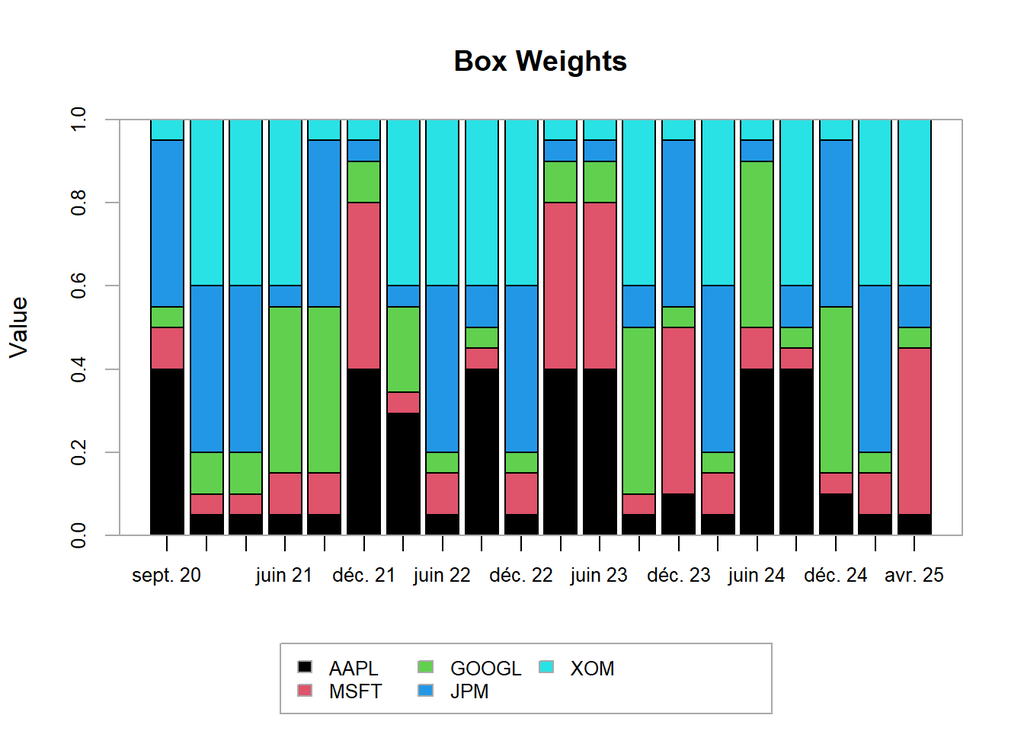

```r
box_port_spec <- port_spec

box_port_spec <- add.constraint(portfolio = box_port_spec,
                                type = "box",
                                min = 0.05, max = 0.4,
                                indexnum = 2)

opt_box = optimize.portfolio.rebalancing(R = returns,
                                         optimize_method = "ROI",
                                         portfolio = box_port_spec,
                                         rebalance_on = "quarters",
                                         training_period = 60,
                                         rolling_window = 60)

box_returns <- Return.portfolio(returns, extractWeights(opt_box))
colnames(box_returns) <- "box"

chart.Weights(opt_box, main = "Box Weights")
```

```r
ret <- cbind(benchmark_returns, base_returns, box_returns)

table.AnnualizedReturns(ret)
```

```
##                           benchmark   base    box
## Annualized Return            0.2616 0.2034 0.1735
## Annualized Std Dev           0.2038 0.2662 0.2132
## Annualized Sharpe (Rf=0%)    1.2835 0.7640 0.8138
```

Base Weights: unconstrained optimizer Box Weight: box constraints (min 5%, max 40% per asset)

- The **unconstrained weighted portfolio** shows extreme concentration patterns, often allocating nearly 100% to a single asset. This explains both the higher volatility and lower Sharpe ratio compared to the benchmark.
- The **box weighted portfolio** shows a more balanced distribution among all five assets throughout the period. This results in lower volatility than the base portfolio, improving the Sharpe ratio despite lower returns.

### Key Takeaways

- **Unconstrained optimization** can lead to extreme, concentrated bets, increasing risk and sometimes reducing risk-adjusted returns.
- **Box constraints** force diversification, lowering risk and often improving the Sharpe ratio, even if raw returns decrease.
- **Simple strategies** like equal-weighting can outperform more complex optimization in both return and risk-adjusted terms, especially when optimizer overfit or ignore diversification.